# Phân tích Dự báo Nhu cầu & Tối ưu hóa Tồn kho — Phase 2

## Bước 7: Monte Carlo Simulation — Mô phỏng Rủi ro Tồn kho

Chạy **10,000 lần mô phỏng** biến động nhu cầu theo phân phối Normal(μ, σ) cho từng Category.

Với mỗi mức Q được thử, tính tổng chi phí kỳ vọng:

- Nếu **Demand > Q**: Chi phí thiếu hàng = Cu × (Demand − Q)
- Nếu **Demand < Q**: Chi phí lưu kho = Co × (Q − Demand)

Q_mc* là mức Q cho **tổng chi phí kỳ vọng thấp nhất** — dùng để cross-validate Q* Newsvendor.

> ✅ Kết quả được coi là hợp lệ nếu |Q_mc* − Q_nv*| < 10%

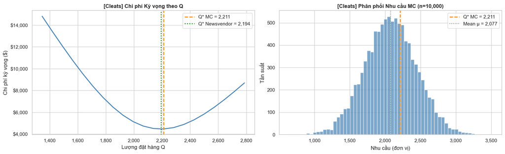

```
[Cleats] Q* Newsvendor = 2,194  |  Q* Monte Carlo = 2,211
  Chênh lệch: 0.8%  →  ✅ Hợp lệ
```

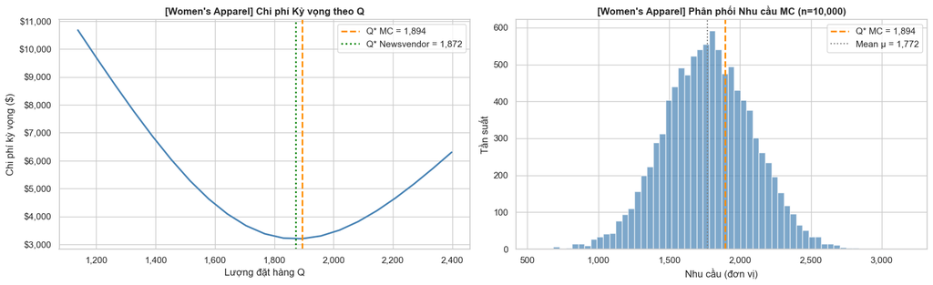

```
[Women's Apparel] Q* Newsvendor = 1,872  |  Q* Monte Carlo = 1,894
  Chênh lệch: 1.2%  →  ✅ Hợp lệ
```

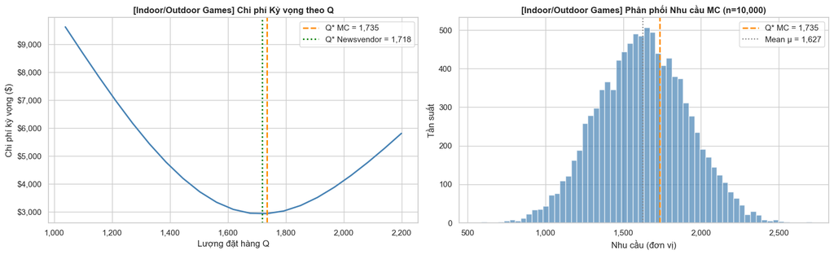

```
[Indoor/Outdoor Games] Q* Newsvendor = 1,718  |  Q* Monte Carlo = 1,735
  Chênh lệch: 1.0%  →  ✅ Hợp lệ
```

```python
np.random.seed(42)
N_SIMULATIONS = 10_000
mc_results_all = {}

for r in newsvendor_results:
    cat       = r['Category']
    mu        = r['Mean Demand μ']
    sigma     = r['Std Dev σ']
    cu        = r['Cu Stockout $']
    co        = r['Co Holding $']
    q_star_nv = r['Q* (đv/tháng)']

    # Dải Q cần thử: μ ± 2σ
    q_range = np.arange(max(0, int(mu - 2*sigma)),
                        int(mu + 2*sigma) + 1,
                        max(1, int(sigma / 5)))

    # Mô phỏng nhu cầu
    demands = np.maximum(np.random.normal(loc=mu, scale=sigma, size=N_SIMULATIONS), 0)

    # Tính chi phí kỳ vọng cho từng mức Q
    expected_costs = []
    for q in q_range:
        overstock  = np.maximum(q - demands, 0)
        understock = np.maximum(demands - q, 0)
        expected_costs.append((co * overstock + cu * understock).mean())

    q_mc_star = int(q_range[np.argmin(expected_costs)])
    mc_results_all[cat] = {
        'q_range': q_range, 'expected_costs': expected_costs,
        'q_mc_star': q_mc_star, 'q_star_nv': q_star_nv, 'demands': demands
    }

    # ── Biểu đồ ──────────────────────────────────────────────
    fig, axes = plt.subplots(1, 2, figsize=(16, 5))

    # Cost curve
    axes[0].plot(q_range, expected_costs, color='steelblue', linewidth=2)
    axes[0].axvline(x=q_mc_star, color='darkorange', linestyle='--', linewidth=2,
                    label=f'Q* MC = {q_mc_star:,}')
    axes[0].axvline(x=q_star_nv, color='green',      linestyle=':',  linewidth=2,
                    label=f'Q* Newsvendor = {q_star_nv:,}')
    axes[0].set_title(f'[{cat}] Chi phí Kỳ vọng theo Q', fontsize=12, fontweight='bold')
    axes[0].set_xlabel('Lượng đặt hàng Q')
    axes[0].set_ylabel('Chi phí kỳ vọng ($)')
    axes[0].yaxis.set_major_formatter(mticker.FuncFormatter(lambda x, _: f'${x:,.0f}'))
    axes[0].xaxis.set_major_formatter(mticker.FuncFormatter(lambda x, _: f'{x:,.0f}'))
    axes[0].legend()

    # Phân phối nhu cầu MC
    axes[1].hist(demands, bins=60, color='steelblue', alpha=0.7, edgecolor='white')
    axes[1].axvline(x=q_mc_star, color='darkorange', linestyle='--', linewidth=2,
                    label=f'Q* MC = {q_mc_star:,}')
    axes[1].axvline(x=mu, color='gray', linestyle=':', linewidth=1.5,
                    label=f'Mean μ = {mu:,.0f}')
    axes[1].set_title(f'[{cat}] Phân phối Nhu cầu MC (n={N_SIMULATIONS:,})', fontsize=12, fontweight='bold')
    axes[1].set_xlabel('Nhu cầu (đơn vị)')
    axes[1].set_ylabel('Tần suất')
    axes[1].xaxis.set_major_formatter(mticker.FuncFormatter(lambda x, _: f'{x:,.0f}'))
    axes[1].legend()

    plt.tight_layout()
    plt.show()

    diff_pct = abs(q_mc_star - q_star_nv) / max(q_star_nv, 1) * 100
    status   = '✅ Hợp lệ' if diff_pct < 10 else '⚠️ Chênh lệch lớn — cần xem lại'
    print(f'[{cat}] Q* Newsvendor = {q_star_nv:,}  |  Q* Monte Carlo = {q_mc_star:,}')
    print(f'  Chênh lệch: {diff_pct:.1f}%  →  {status}')
```